# DATA 622 HW3 - Classification using KNN, Decision Trees, Random Forests and Gradient Boosting

Mael Illien, Dhairav Chhatbar, Santosh Manjrekar

3/19/2021

## Setup

```r
library(skimr)
library(tidyverse)
library(caret) # For featureplot, classification report
library(corrplot) # For correlation matrix
library(AppliedPredictiveModeling)
library(mice) # For data imputation
library(VIM) # For missing data visualization
library(gridExtra) # For grid plots
library(rpart) # For Decision Trees models
library(rpart.plot) # For Decision Tree Plots
library(randomForest) # For Random Forest models
library(randomForestExplainer) # For Random Forest Variable Importance Analysis
library (gbm) #Gradient Boosting
```

# Penguins Dataset

## Data Exploration

The penguin dataset is composed of 344 observations with 8 variables, 5 of which are numeric and 3 which are qualitative. The dataset is mostly complete with just a few observations with missing values that will need to be handled.

Data summary

| Name | penguins |
| --- | --- |
| Number of rows | 344 |
| Number of columns | 8 |
| _______________________ |  |
| Column type frequency: |  |
| factor | 3 |
| numeric | 5 |
| ________________________ |  |
| Group variables | None |

**Variable type: factor**

| skim_variable | n_missing | complete_rate | ordered | n_unique | top_counts |
| --- | --- | --- | --- | --- | --- |
| species | 0 | 1.00 | FALSE | 3 | Ade: 152, Gen: 124, Chi: 68 |
| island | 0 | 1.00 | FALSE | 3 | Bis: 168, Dre: 124, Tor: 52 |
| sex | 11 | 0.97 | FALSE | 2 | mal: 168, fem: 165 |

**Variable type: numeric**

| skim_variable | n_missing | complete_rate | mean | sd | p0 | p25 | p50 | p75 | p100 | hist |
| --- | --- | --- | --- | --- | --- | --- | --- | --- | --- | --- |
| bill_length_mm | 2 | 0.99 | 43.92 | 5.46 | 32.1 | 39.23 | 44.45 | 48.5 | 59.6 | ▃▇▇▆▁ |
| bill_depth_mm | 2 | 0.99 | 17.15 | 1.97 | 13.1 | 15.60 | 17.30 | 18.7 | 21.5 | ▅▅▇▇▂ |
| flipper_length_mm | 2 | 0.99 | 200.92 | 14.06 | 172.0 | 190.00 | 197.00 | 213.0 | 231.0 | ▂▇▃▅▂ |
| body_mass_g | 2 | 0.99 | 4201.75 | 801.95 | 2700.0 | 3550.00 | 4050.00 | 4750.0 | 6300.0 | ▃▇▆▃▂ |
| year | 0 | 1.00 | 2008.03 | 0.82 | 2007.0 | 2007.00 | 2008.00 | 2009.0 | 2009.0 | ▇▁▇▁▇ |

| species | island | bill_length_mm | bill_depth_mm | flipper_length_mm | body_mass_g | sex | year |
| --- | --- | --- | --- | --- | --- | --- | --- |
| Adelie | Torgersen | 39.1 | 18.7 | 181 | 3750 | male | 2007 |
| Adelie | Torgersen | 39.5 | 17.4 | 186 | 3800 | female | 2007 |
| Adelie | Torgersen | 40.3 | 18.0 | 195 | 3250 | female | 2007 |
| Adelie | Torgersen | NA | NA | NA | NA | NA | 2007 |
| Adelie | Torgersen | 36.7 | 19.3 | 193 | 3450 | female | 2007 |
| Adelie | Torgersen | 39.3 | 20.6 | 190 | 3650 | male | 2007 |
| Adelie | Torgersen | 38.9 | 17.8 | 181 | 3625 | female | 2007 |
| Adelie | Torgersen | 39.2 | 19.6 | 195 | 4675 | male | 2007 |
| Adelie | Torgersen | 34.1 | 18.1 | 193 | 3475 | NA | 2007 |
| Adelie | Torgersen | 42.0 | 20.2 | 190 | 4250 | NA | 2007 |

[output cut: 334 more lines]

The target variable of interest is the species of penguins, which are categorized into three groups: Adelie, Gentoo and Chinstrap penguins.

```
## [1] Adelie    Gentoo    Chinstrap
## Levels: Adelie Chinstrap Gentoo
```

### Species Distribution on Islands

From this plot, we can make a few key observations:

- Gentoo penguins are only found on Biscoe Island
- Chinstrap pengiuns only found on Dream Island
- Adelie penguins are found on all three islands
- Torgersen Island only has Adelie penguins

These island observations are valuable information in differentiating penguin species.

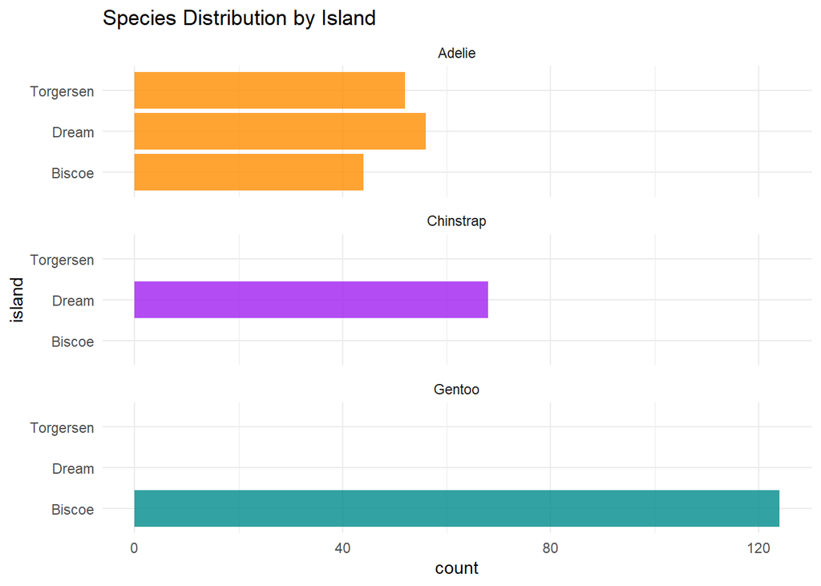

### Sex Distribution

However, the sex of the penguins does not offer much information as the proportion is about even across all species. We can also note a few missing observations labeled as NA.

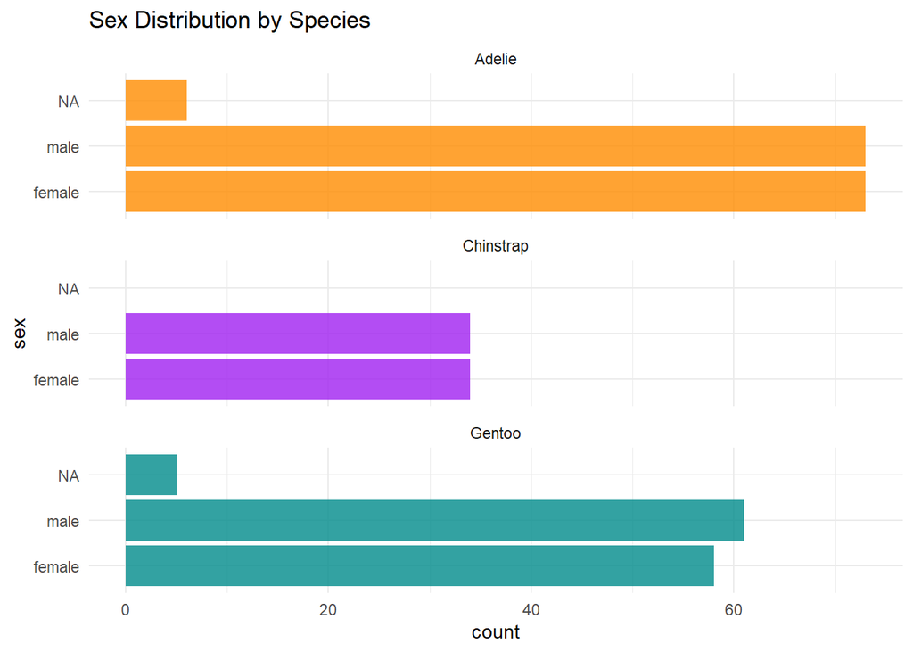

### Missing Values & Variable Selection

We noted from the data summary above that 11 observations were missing for the `sex` variable. There is also no reason to believe that the `year` the observation was taken would have any impact on the morphology of the penguins. We are not looking for any time series modeling. Therefore, we also drop `year` from our predictor variables. There are also two observations which are missing body measurements altogether, so these rows will be dropped altogether.

```r
penguins[!complete.cases(penguins), ]
```

| species | island | bill_length_mm | bill_depth_mm | flipper_length_mm | body_mass_g | sex | year |
| --- | --- | --- | --- | --- | --- | --- | --- |
| Adelie | Torgersen | NA | NA | NA | NA | NA | 2007 |
| Adelie | Torgersen | 34.1 | 18.1 | 193 | 3475 | NA | 2007 |
| Adelie | Torgersen | 42.0 | 20.2 | 190 | 4250 | NA | 2007 |
| Adelie | Torgersen | 37.8 | 17.1 | 186 | 3300 | NA | 2007 |
| Adelie | Torgersen | 37.8 | 17.3 | 180 | 3700 | NA | 2007 |
| Adelie | Dream | 37.5 | 18.9 | 179 | 2975 | NA | 2007 |
| Gentoo | Biscoe | 44.5 | 14.3 | 216 | 4100 | NA | 2007 |
| Gentoo | Biscoe | 46.2 | 14.4 | 214 | 4650 | NA | 2008 |
| Gentoo | Biscoe | 47.3 | 13.8 | 216 | 4725 | NA | 2009 |
| Gentoo | Biscoe | 44.5 | 15.7 | 217 | 4875 | NA | 2009 |

[output cut: 1 more lines]

```r
penguins <- penguins[complete.cases(penguins), ]
penguins <- dplyr::select(penguins, -c(year, island))
```

### Body Measurements

When looking at body measurements we see that Adelie and Chinstrap penguins largely overlap except for `bill_length`. This suggests that we might be able to use `bill_depth`, `body_mass` and `flipper_length` to differentiate the Gentoo penguins from the other species. However, the Adelie penguin stands out from the other others in `bill_length`

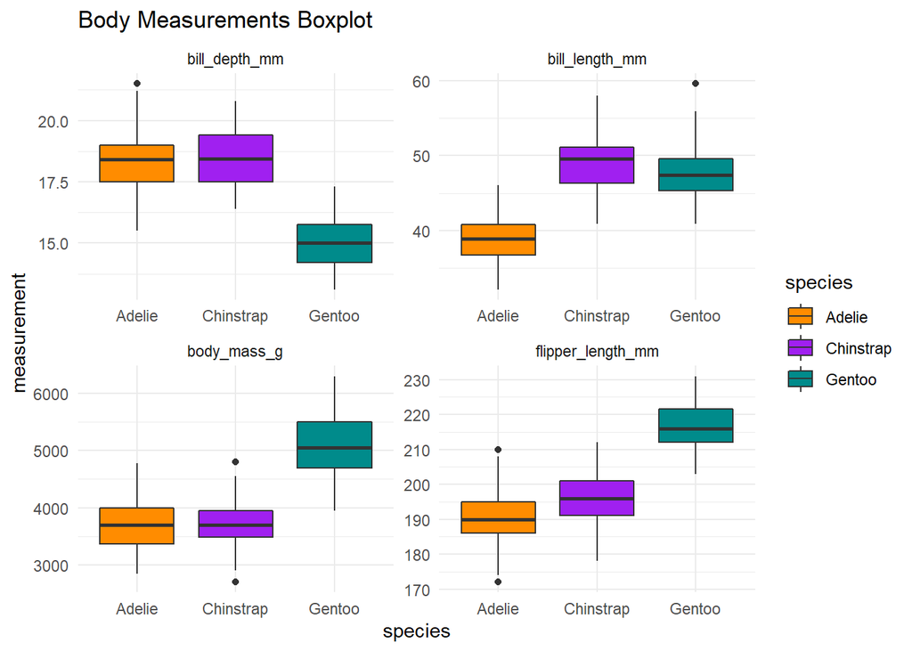

The scatterplot matrix below is another way to visualize the separation and overlap between classes for different combination of variables. We see that in general, Gentoo penguins standalone as a separate group. However, Adelie and Chinstrap penguins overlap in the comparison of `bill_depth`, `flipper_length` and `body_mass`.

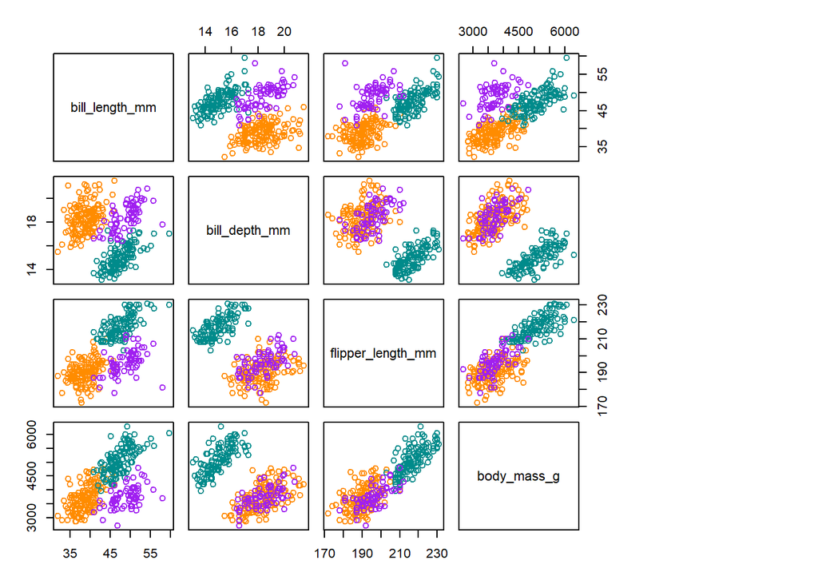

We see on the univariate feature plots below that the data is aproximatelly normally distributed.

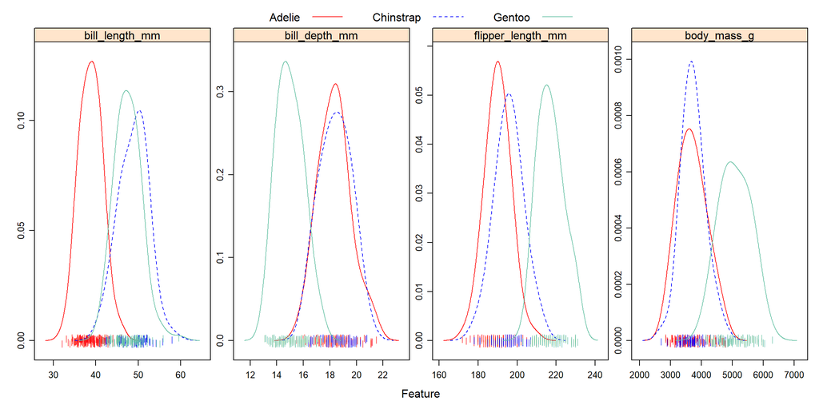

### Multicollinearity

Taking a look at the correlation matrix below, we can make a few observations, notably that `flipper_length` is highly positively correlated with `body_mass` which makes sense given that larger penguins should have larger flippers. The other correlations are less obvious to interpret. Given that the dataset only contains a few predictors, we choose not to exclude any variables based on multicollinearity at this time.

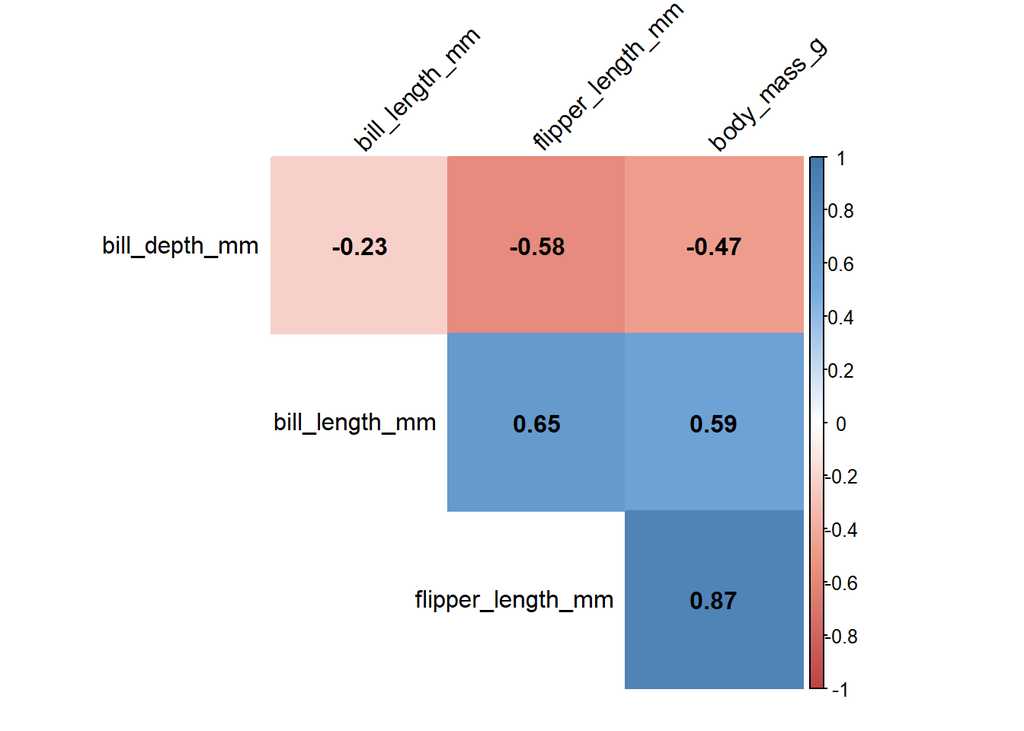

## K-Nearest Neighbors

The KNN algorithms requires minor data processing. Firstly, predictor values that are factors should be conversted to numeric. Secondly, because KNN uses distance between points to determine their classification, it is important for the points to be on the scaled appropriately. Here we pass the `scale` argument to the `preProcess` parameter of the training function to standardize each variable. The data is then split into training and testing sets 80%/20%. The test set contains 65 observations and the train set 268 observations.

### Processing

```r
# Processing
penguins_knn <- penguins
penguins_knn$sex <- as.numeric(penguins_knn$sex)-1 # recode as 1 or 0
# Data Partitioning
set.seed(622)
trainIndex <- createDataPartition(penguins_knn$species, p = .8, list = FALSE, times = 1)
knn_training <- penguins_knn[trainIndex,]
knn_testing  <- penguins_knn[-trainIndex,]
```

### Modeling

We performed 10-fold cross-validation in the training data to determine the optimal parameter k for our model. The resulting accuracy for each value of k is displayed and plotted below. The maximum accuracy is reached with values of k=3 and k=4 but the training procedure automatically chose k=4 as the best model. We gain a full percentage point in cross-validation accuracy on the training data using the tuned model over models with slightly more or fewer neighbors.

```r
trControl <- trainControl(method  = "cv",
                          number  = 10)
knn.fit <- train(species ~ .,
             method     = "knn",
             tuneGrid   = expand.grid(k = 1:10),
             trControl  = trControl,
             preProcess = c("center","scale"),
             metric     = "Accuracy",
             data       = knn_training)
```

```r
knn.fit
```

```
## k-Nearest Neighbors
##
## 268 samples
##   5 predictor
##   3 classes: 'Adelie', 'Chinstrap', 'Gentoo'
##
## Pre-processing: centered (5), scaled (5)
## Resampling: Cross-Validated (10 fold)
## Summary of sample sizes: 241, 241, 240, 242, 241, 242, ...
## Resampling results across tuning parameters:
##
##   k   Accuracy   Kappa
##    1  0.9851852  0.9769336
##    2  0.9850427  0.9765099
##    3  0.9962963  0.9941558
##    4  0.9962963  0.9941558
##    5  0.9887464  0.9821064
##    6  0.9851750  0.9764839
##    7  0.9851750  0.9764839
##    8  0.9888787  0.9823281
##    9  0.9888787  0.9823281
##   10  0.9888787  0.9823281
##
## Accuracy was used to select the optimal model using the largest value.
## The final value used for the model was k = 4.
```

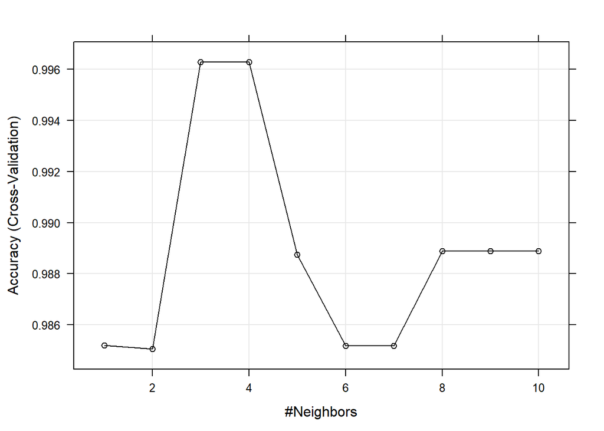

### Results

The evaluation of the tuned K-NN model on the testing data reveals that the model was able to classify species with perfect accuracy. However, it is important to note that 100% prediction accuracy is typically rare and that this model benefitted from fairly clean class separations and limited overlap in the original dataset.

```r
knnPredict <- predict(knn.fit, newdata = knn_testing)
confusionMatrix(knnPredict, knn_testing$species)
```

```
## Confusion Matrix and Statistics
##
##            Reference
## Prediction  Adelie Chinstrap Gentoo
##   Adelie        29         0      0
##   Chinstrap      0        13      0
##   Gentoo         0         0     23
##
## Overall Statistics
##
##                Accuracy : 1
##                  95% CI : (0.9448, 1)
##     No Information Rate : 0.4462
##     P-Value [Acc > NIR] : < 2.2e-16
##
##                   Kappa : 1
##
##  Mcnemar's Test P-Value : NA
##
## Statistics by Class:
##
##                      Class: Adelie Class: Chinstrap Class: Gentoo
## Sensitivity                 1.0000              1.0        1.0000
## Specificity                 1.0000              1.0        1.0000
## Pos Pred Value              1.0000              1.0        1.0000
## Neg Pred Value              1.0000              1.0        1.0000
## Prevalence                  0.4462              0.2        0.3538
## Detection Rate              0.4462              0.2        0.3538
## Detection Prevalence        0.4462              0.2        0.3538
## Balanced Accuracy           1.0000              1.0        1.0000
```

# Loan Approval Dataset

A loan-issuance company with presence across urban, semi urban and rural areas wants to validate the eligibility of customers to be granted a loan. Using an online application form, customers enter a series of attributes such as Gender, Marital Status, Education, Number of Dependents, Income, Loan Amount, Credit History and others. To automate the eligibility process, multiple supervised classification approaches can be used. In our case, we explore tree-based methods starting from simple Decision Trees (DT). Ensemble methods such as Random Forests (RF) and Gradient Boosting (GB) are also used to improve on the classification accuracy of the simple DT.

The loan dataset is composed of 13 variables and 614 observations. The target or dependent variable is `Loan_Status` and contains ‘Y’ or ‘N’ as entries. Predicting whether a long will be approved is a binary classification problem.

Eight of the variables are factors and 5 are numeric. The dataset contains missing values recorded either as ‘NA’ or simply empty. Some columns are missing nearly 10% of observations. Imputation of the missing values will be a step in the data pre-processing. We also note that the Loan_ID variable is simply an index and holds no valuable information, making it safe for removal. The Credit_History variable is coded as numeric but it is a binary variable with two levels.

```r
loan_raw <- read.csv('https://raw.githubusercontent.com/maelillien/data622/main/hw3/Loan_approval.csv', header = TRUE)
loan_raw <- loan_raw %>% mutate_if(is.character, factor)
loan <- loan_raw
```

```r
head(loan)
```

|  | Loan_ID | Gender | Married | Dependents | Education | Self_Employed | ApplicantIncome | CoapplicantIncome | LoanAmount | Loan_Amount_Term | Credit_History | Property_Area | Loan_Status |
| --- | --- | --- | --- | --- | --- | --- | --- | --- | --- | --- | --- | --- | --- |
| 1 | LP001002 | Male | No | 0 | Graduate | No | 5849 | 0 | NA | 360 | 1 | Urban | Y |
| 2 | LP001003 | Male | Yes | 1 | Graduate | No | 4583 | 1508 | 128 | 360 | 1 | Rural | N |
| 3 | LP001005 | Male | Yes | 0 | Graduate | Yes | 3000 | 0 | 66 | 360 | 1 | Urban | Y |
| 4 | LP001006 | Male | Yes | 0 | Not Graduate | No | 2583 | 2358 | 120 | 360 | 1 | Urban | Y |
| 5 | LP001008 | Male | No | 0 | Graduate | No | 6000 | 0 | 141 | 360 | 1 | Urban | Y |
| 6 | LP001011 | Male | Yes | 2 | Graduate | Yes | 5417 | 4196 | 267 | 360 | 1 | Urban | Y |

```r
# replace blank values with NA to allow for proper calculation of the complete_rate column in the data summary
loan[loan==''] <- NA
skim(loan)
```

Data summary

| Name | loan |
| --- | --- |
| Number of rows | 614 |
| Number of columns | 13 |
| _______________________ |  |
| Column type frequency: |  |
| factor | 8 |
| numeric | 5 |
| ________________________ |  |
| Group variables | None |

**Variable type: factor**

| skim_variable | n_missing | complete_rate | ordered | n_unique | top_counts |
| --- | --- | --- | --- | --- | --- |
| Loan_ID | 0 | 1.00 | FALSE | 614 | LP0: 1, LP0: 1, LP0: 1, LP0: 1 |
| Gender | 13 | 0.98 | FALSE | 2 | Mal: 489, Fem: 112, emp: 0 |
| Married | 3 | 1.00 | FALSE | 2 | Yes: 398, No: 213, emp: 0 |
| Dependents | 15 | 0.98 | FALSE | 4 | 0: 345, 1: 102, 2: 101, 3+: 51 |
| Education | 0 | 1.00 | FALSE | 2 | Gra: 480, Not: 134 |
| Self_Employed | 32 | 0.95 | FALSE | 2 | No: 500, Yes: 82, emp: 0 |
| Property_Area | 0 | 1.00 | FALSE | 3 | Sem: 233, Urb: 202, Rur: 179 |
| Loan_Status | 0 | 1.00 | FALSE | 2 | Y: 422, N: 192 |

**Variable type: numeric**

| skim_variable | n_missing | complete_rate | mean | sd | p0 | p25 | p50 | p75 | p100 | hist |
| --- | --- | --- | --- | --- | --- | --- | --- | --- | --- | --- |
| ApplicantIncome | 0 | 1.00 | 5403.46 | 6109.04 | 150 | 2877.5 | 3812.5 | 5795.00 | 81000 | ▇▁▁▁▁ |
| CoapplicantIncome | 0 | 1.00 | 1621.25 | 2926.25 | 0 | 0.0 | 1188.5 | 2297.25 | 41667 | ▇▁▁▁▁ |
| LoanAmount | 22 | 0.96 | 146.41 | 85.59 | 9 | 100.0 | 128.0 | 168.00 | 700 | ▇▃▁▁▁ |
| Loan_Amount_Term | 14 | 0.98 | 342.00 | 65.12 | 12 | 360.0 | 360.0 | 360.00 | 480 | ▁▁▁▇▁ |
| Credit_History | 50 | 0.92 | 0.84 | 0.36 | 0 | 1.0 | 1.0 | 1.00 | 1 | ▂▁▁▁▇ |

## Data Pre-processing

The pre-processing steps are the following:

- Creating a new variable called `TotalIncome` by summing applicant and coapplicant incomes. Typically loan issuers take into account the combined income of the applicant and guarantor.
- Dropping the valueless variable `Loan_ID` and the individual income variables that were just combined.
- Treating `Credit_History` as a factor with 2 levels instead of a numeric variables
- Imputation of missing values

Note that the tree based methods employed in this exercise are not required to be coded as numeric or expanded as dummy variables. We can see from the data summary above that the remainder of the variables have the proper data type.

```r
loan <- loan %>% mutate(TotalIncome = ApplicantIncome + CoapplicantIncome)
loan <- loan %>% select(-c('Loan_ID','ApplicantIncome','CoapplicantIncome'))
loan$Credit_History <- as.factor(loan$Credit_History)
```

#### Imputation of Missing Values

Looking at the Pattern plot of missing values, we see a slight discernible pattern from variable to variable and observation to observation. Therefore this dataset has missing values at random (MAR), such that the probability of value of a given missing predictor observation depends on a observed value of a different predictor variable.

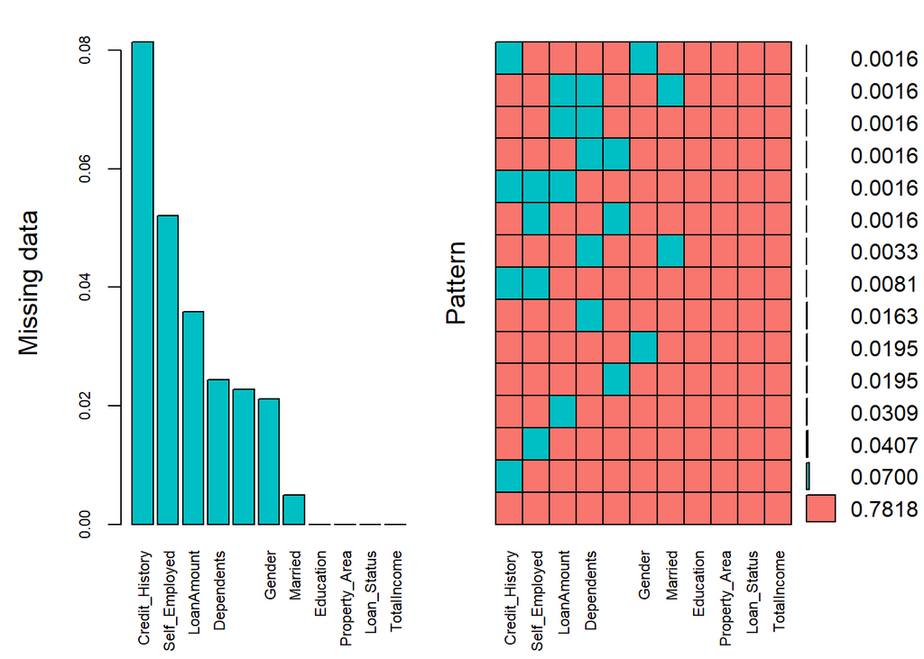

```
##
##  Variables sorted by number of missings:
##          Variable       Count
##    Credit_History 0.081433225
##     Self_Employed 0.052117264
##        LoanAmount 0.035830619
##        Dependents 0.024429967
##  Loan_Amount_Term 0.022801303
##            Gender 0.021172638
##           Married 0.004885993
##         Education 0.000000000
##     Property_Area 0.000000000
##       Loan_Status 0.000000000
##       TotalIncome 0.000000000
```

Given this assumption, we can use the MICE (Multivariate Imputation via Chained Equations) package to impute the missing values throughout the dataset. For each type of predictor variable we will use:

- Numeric Variables: Predictive Mean Matching (ppm)
- Binary Variables: Logistic Regression (logreg)
- Factor Variables (3+ levels): Bayesian Polytomous Regression

```r
# pmm for numerical variables, logreg for binary factor variables and polyreg for multilevel factor variables
init <- mice(loan, maxit=0)
meth <- init$method
predM <- init$predictorMatrix
meth[c('LoanAmount', 'Loan_Amount_Term')] <- 'pmm'
meth[c('Credit_History','Self_Employed','Gender','Married')] <- 'logreg'
meth[c('Dependents')] <- 'polyreg'
meth[c('Loan_Status','TotalIncome','Property_Area','Education')] = ''
imputed <- mice(loan, method=meth, predictorMatrix=predM, m=5, seed=500)
loan <- complete(imputed)
table(complete.cases(loan))
```

```
##
## TRUE
##  614
```

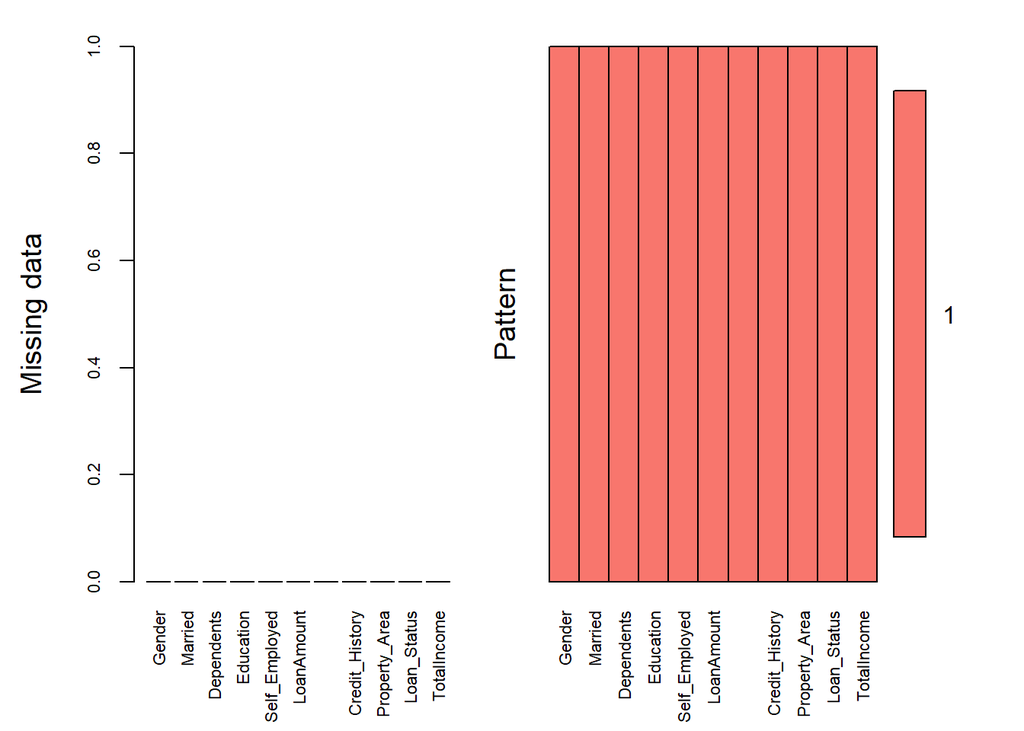

```
##
##  Variables sorted by number of missings:
##          Variable Count
##            Gender     0
##           Married     0
##        Dependents     0
##         Education     0
##     Self_Employed     0
##        LoanAmount     0
##  Loan_Amount_Term     0
##    Credit_History     0
##     Property_Area     0
##       Loan_Status     0
##       TotalIncome     0
```

```r
mice_plot <- aggr(loan, col=c('#F8766D','#00BFC4'), numbers=TRUE, sortVars=TRUE, labels=names(loan), cex.axis=.7, gap=3, ylab=c("Missing data","Pattern"))
```

```r
meth
```

```
##           Gender          Married       Dependents        Education
##         "logreg"         "logreg"        "polyreg"               ""
##    Self_Employed       LoanAmount Loan_Amount_Term   Credit_History
##         "logreg"            "pmm"            "pmm"         "logreg"
##    Property_Area      Loan_Status      TotalIncome
##               ""               ""               ""
```

## Data Exploration

By examining the target variables, we see that nearly 70% of all loans are approved.

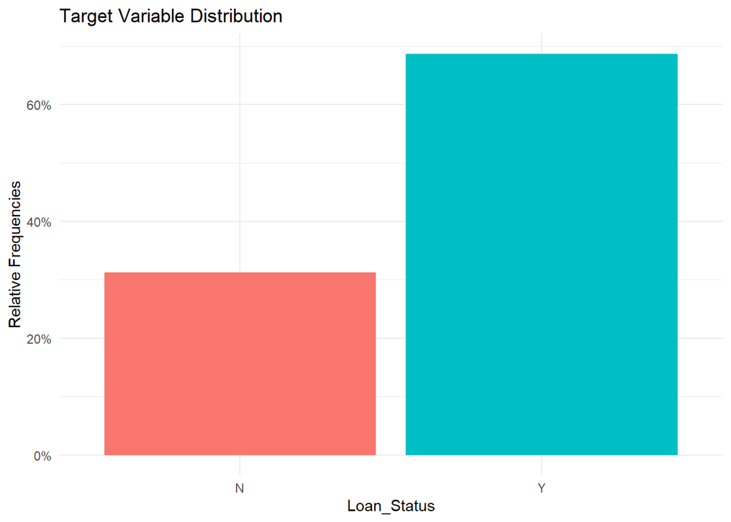

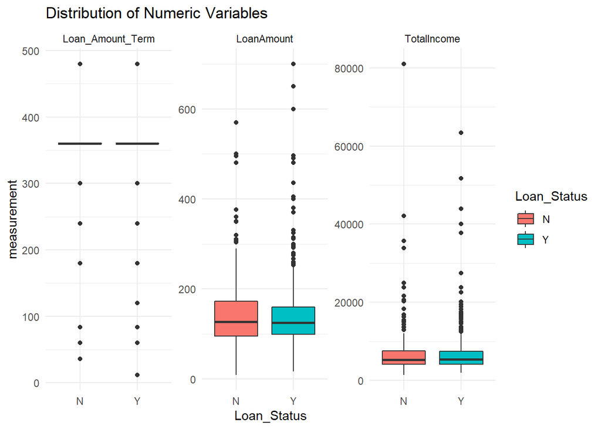

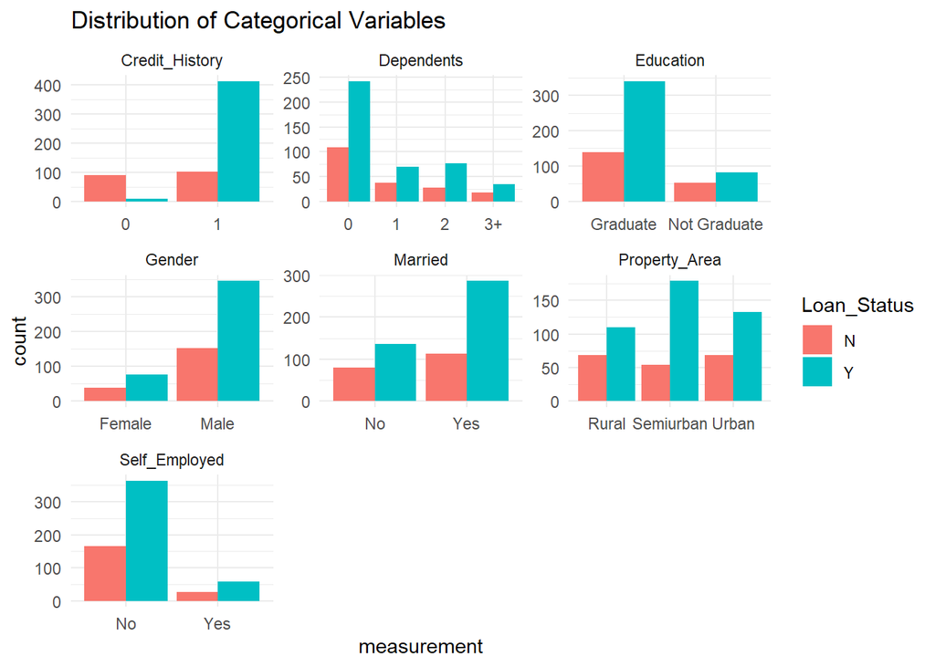

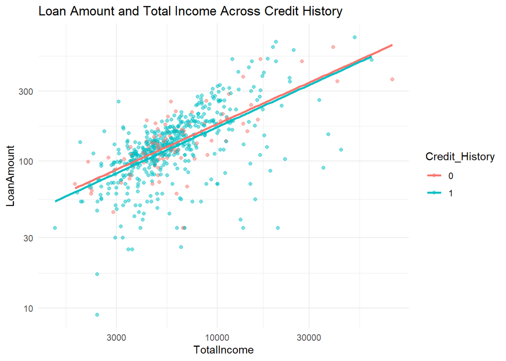

The least squares lines across the dependent variable are also nearly collinear but the line representing individuals who received loans has a slightly greater slope suggesting that higher incomes unlock larger loans which is sensible and expected.

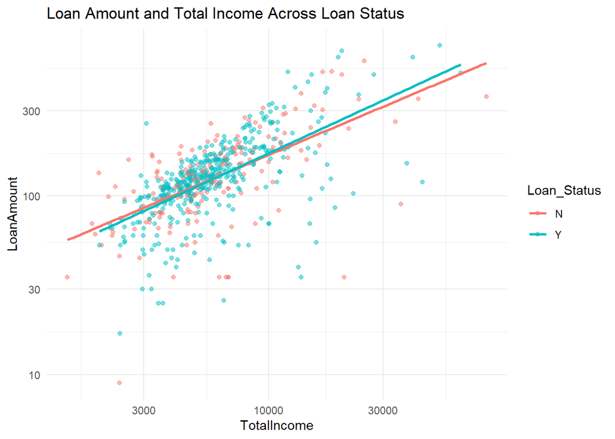

Other than credit history, total income (applicant income + coapplicant income) seems like the most logical basis for approving or denying a loan. The histograms below compare total income across all levels of the categorical variables. Total income is skewed to the right tail, with a few observations at the higher end of the log-transformed income scale.

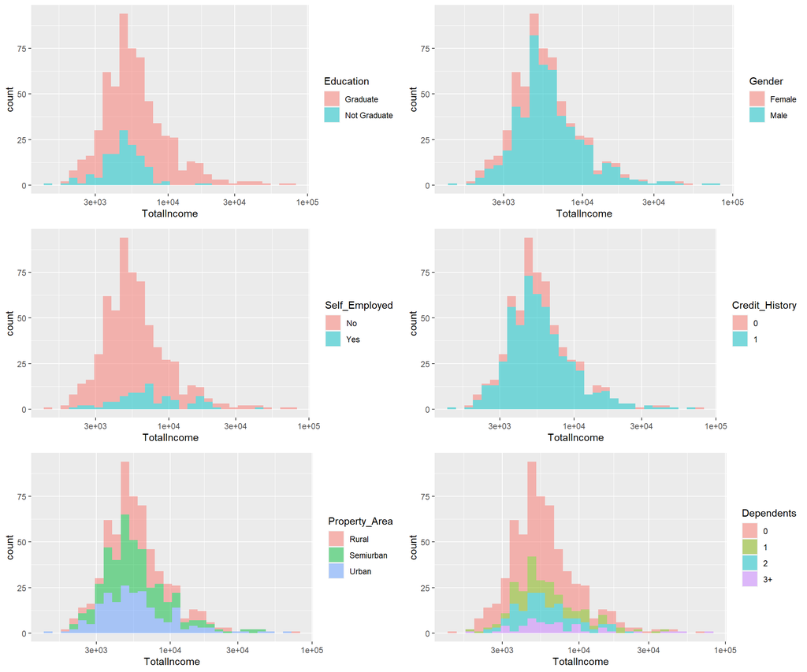

## Data Processing

The data pre-processing section the structural form of the data. No additional processing is required for tree-based methods. We partition our data into training and testing sets in a 70%/30% proportion.

```r
set.seed(622)
trainIndex <- createDataPartition(loan$Loan_Status, p = .7, list = FALSE, times = 1)
training <- loan[ trainIndex,]
testing  <- loan[-trainIndex,]
```

## Decision Trees

A Decision Tree is a type of supervised learning model where the data is recursively split into two or more sub-populations given a criteria. Each split is headed by a node, where the upper most node is called the root node, and nodes resulting in no more additional splits called terminal (leaf) nodes. All other nodes are considered internal nodes. Based on a given population of observations, the population is split into sub-populations with the criteria that each split distinguishes the sub-population better than the previous split. This splitting recursively continues on different predictor variables such that a leaf nodes can make accurate predictions/conclusions on a given observation

The Decision Tree model can be used for regression and classification. In this case we use the model for classification of loan approvals

### Simple Tree

The 1st step is to grow a baseline decision tree based on splits generating the most Information Gain, which is based on the decrease in entropy after a dataset is split on a given attribute.

Post growing a baseline tree we will need to decide if it requires purning so that we can remove leaf nodes for which we are not able to draw accurate conclusions on. Given that we want to do this, the Cost Complexity parameter set to 0.

The Cost Complexity parameter is slightly different from Information Gain and Gini index, but conceptually it is similar. The parameter the amount by which splitting a given node improved the relative error, in other words, it is the minimum improvement in the overall model needed at each node to justify the split.

```r
loan_dt <- rpart(Loan_Status ~., data = training, method = "class",
                 parms = list(split="information"), control = rpart.control(cp=0))
loan_dt
```

```
## n= 431
##
## node), split, n, loss, yval, (yprob)
##       * denotes terminal node
##
##   1) root 431 135 Y (0.31322506 0.68677494)
##     2) Credit_History=0 73   6 N (0.91780822 0.08219178) *
##     3) Credit_History=1 358  68 Y (0.18994413 0.81005587)
##       6) TotalIncome< 2457 8   2 N (0.75000000 0.25000000) *
##       7) TotalIncome>=2457 350  62 Y (0.17714286 0.82285714)
##        14) TotalIncome>=20199.5 11   5 N (0.54545455 0.45454545) *
##        15) TotalIncome< 20199.5 339  56 Y (0.16519174 0.83480826)
##          30) Loan_Amount_Term>=420 10   5 N (0.50000000 0.50000000) *
##          31) Loan_Amount_Term< 420 329  51 Y (0.15501520 0.84498480)
##            62) Property_Area=Rural 92  21 Y (0.22826087 0.77173913)
##             124) TotalIncome< 3606.5 9   4 N (0.55555556 0.44444444) *
##             125) TotalIncome>=3606.5 83  16 Y (0.19277108 0.80722892)
##               250) Dependents=1 7   3 N (0.57142857 0.42857143) *
##               251) Dependents=0,2,3+ 76  12 Y (0.15789474 0.84210526) *
##            63) Property_Area=Semiurban,Urban 237  30 Y (0.12658228 0.87341772)
##             126) TotalIncome>=3416 215  30 Y (0.13953488 0.86046512)
##               252) TotalIncome>=6577 77  15 Y (0.19480519 0.80519481)
##                 504) TotalIncome< 6800 7   2 N (0.71428571 0.28571429) *
##                 505) TotalIncome>=6800 70  10 Y (0.14285714 0.85714286) *
##               253) TotalIncome< 6577 138  15 Y (0.10869565 0.89130435) *
##             127) TotalIncome< 3416 22   0 Y (0.00000000 1.00000000) *
```

Given the baseline tree we see that it is 8 levels deep. Each node shows the predicted class, the probability of that class and the percentage of observations that fall into the given node.

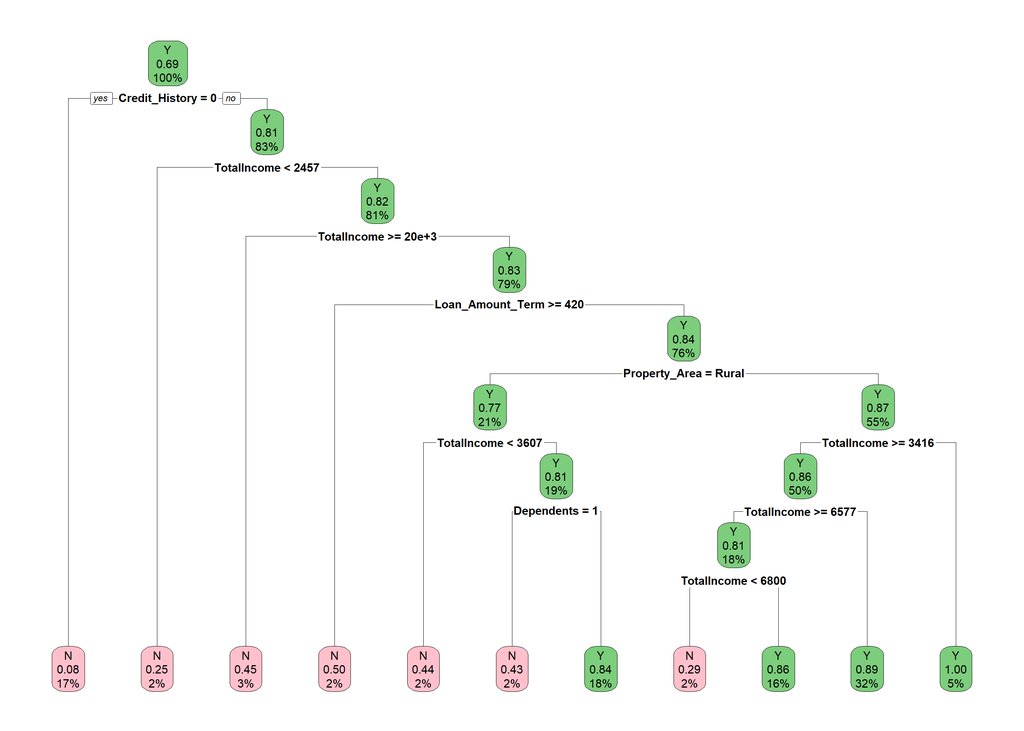

```r
rpart.plot(loan_dt, box.col = c("pink", "palegreen3")[loan_dt$frame$yval])
```

Predict loan_status on test set and calculate accuracy

```r
loan_dt_pred <- predict(loan_dt, testing, type = "class")
loan_dt_table <- table(Actual = testing$Loan_Status, Predicted = loan_dt_pred)
loan_dt_table
```

```
##       Predicted
## Actual   N   Y
##      N  29  28
##      Y  21 105
```

```r
acc_dt_base <-  sum(diag(loan_dt_table))/sum(loan_dt_table)

acc_df<- data.frame(Model = "Base Decision Tree", Accuracy = acc_dt_base)

cat("Accuracy: ", acc_dt_base)
```

```
## Accuracy:  0.7322404
```

### Pruned Tree

We now try to prune the tree based on cross-validated error rates. In other words, we will try to find a Cost Complexity pramater which has the lowest cross-validation error rate and then supply this value back into growing the decision tree, but stop growing past a certain nodes where the cross-validation error rate is not minimal

From the below we see that the error rate is minimized when the tree is only at 2 levels. This indicates the Decision Tree is provides the most accurate predictions at 2 levels, which is just 1 split on Credit History. This is an unrealistic tree and for practical reasons, we chose to find the cost complexity parameter where pruning the tree will result in atleast 2 splits

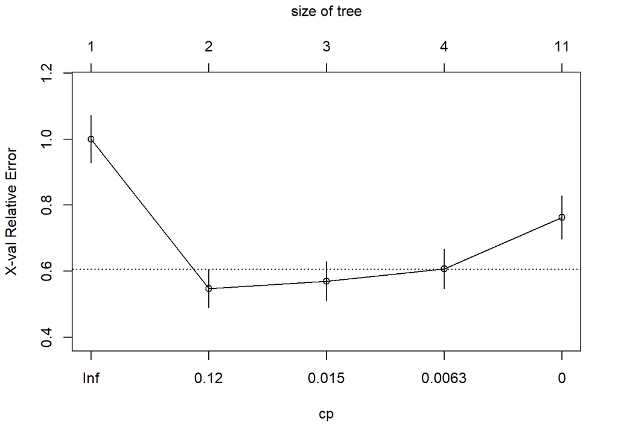

```r
plotcp(loan_dt)
```

```r
#cost complexity parameter where number of splits is greater than 1 AND the cross-validation error is minimum

#min_err <- loan_dt$cptable[which.min(loan_dt$cptable[,"xerror"]),"CP"]
cost_complexity_dt <- data.frame(printcp(loan_dt))
```

```
##
## Classification tree:
## rpart(formula = Loan_Status ~ ., data = training, method = "class",
##     parms = list(split = "information"), control = rpart.control(cp = 0))
##
## Variables actually used in tree construction:
## [1] Credit_History   Dependents       Loan_Amount_Term Property_Area
## [5] TotalIncome
##
## Root node error: 135/431 = 0.31323
##
## n= 431
##
##          CP nsplit rel error  xerror     xstd
## 1 0.4518519      0   1.00000 1.00000 0.071325
## 2 0.0296296      1   0.54815 0.54815 0.057993
## 3 0.0074074      2   0.51852 0.57037 0.058908
## 4 0.0052910      3   0.51111 0.60741 0.060360
## 5 0.0000000     10   0.47407 0.76296 0.065582
```

```r
min_err <- (cost_complexity_dt %>% filter(nsplit > 1) %>% slice(which.min(xerror)))$CP

cat("Minimum Error: ", min_err)
```

```
## Minimum Error:  0.007407407
```

Prune tree based on CP value that has lowest cross validation error rate with atleaset 2 splits. The resulting tree is 3 levels levels and the most significant predictors are Credit History and Total Income

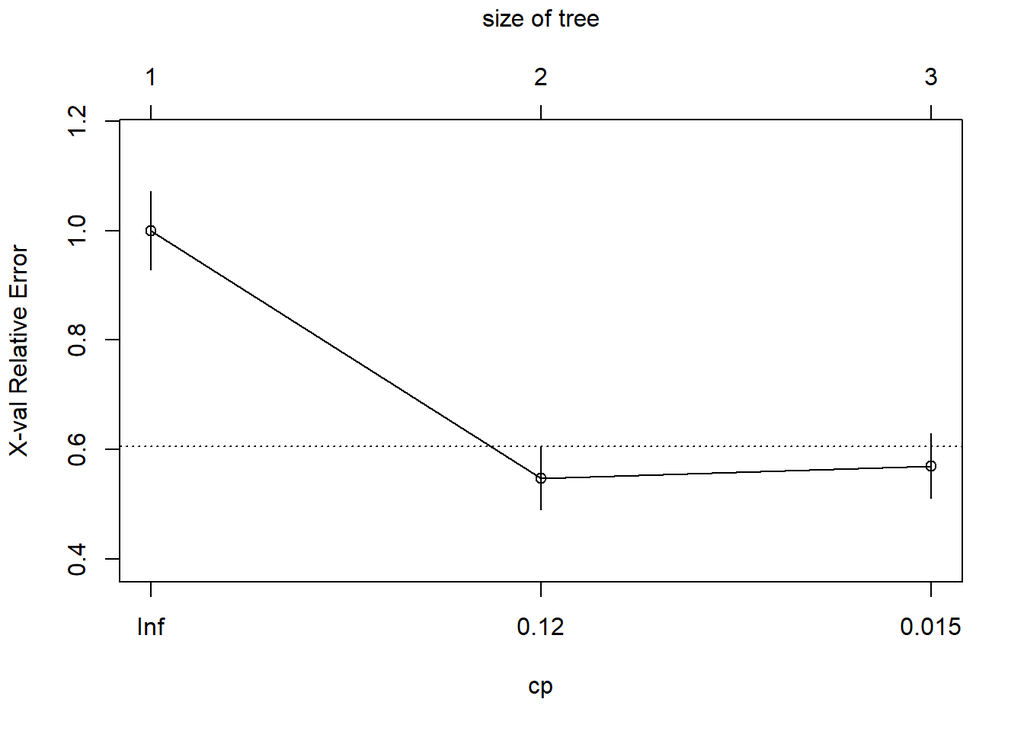

```r
loan_dt_prune <- prune(loan_dt, min_err)
plotcp(loan_dt_prune)
```

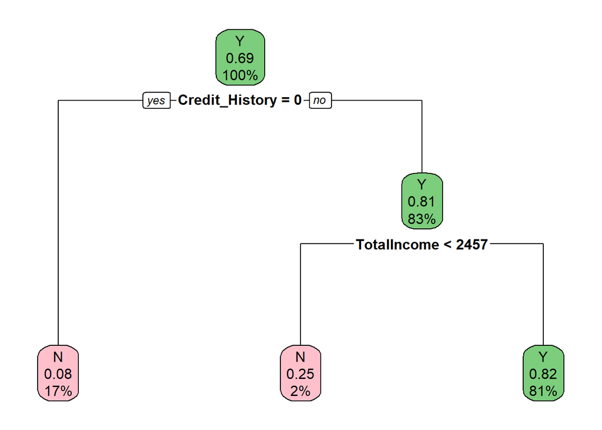

```r
rpart.plot(loan_dt_prune, box.col = c("pink", "palegreen3")[loan_dt$frame$yval])
```

Accuracy of pruned tree

```r
loan_dt_prune_pred <- predict(loan_dt_prune, testing, type = "class")
loan_dt_prune_table <- table(Actual = testing$Loan_Status, Predicted = loan_dt_prune_pred)
loan_dt_prune_table
```

```
##       Predicted
## Actual   N   Y
##      N  25  32
##      Y   7 119
```

```r
acc_dt_prune <-  sum(diag(loan_dt_prune_table))/sum(loan_dt_prune_table)

acc_df <- rbind(acc_df, data.frame(Model = "Pruned Decision Tree", Accuracy =acc_dt_prune))
cat("Accuracy: ", acc_dt_prune)
```

```
## Accuracy:  0.7868852
```

## Random Forest

The Random Forest model is similar to Decision Tree model in terms of how it constructs a tree. The difference is that the Random Forest model is a collection (ensamble) of Decision Trees. Each of these trees in the forest are constructed bootstrapped observations and randomized subset of features. Each tree in the forest then classifies a given observation and then the majority of the classification class is determined as the predicted class for that given observation

To build an optimal forest there are 2 parameters that we can tune:

- ntree: the number of trees in the forest
- mtry: the number of of random variables for each tree

For classification datasets, the generally recommended subset of variables recommended is the squareroot of the total number of predictor variables. In our dataset this is this is 3, since we have 10 total predictor variables

Form the results below we see that 2 random variables per tree in the forest generates the lowest Out of Bag error. In quick summary, when using bootstrapped samples, about a third of the observations do not end up getting used in construction of the trees, and the model’s prediction on these new (to the model) observations is the Out of Bag Error

Therefore we will set the mtry parameter to the number of variables that generate the lowest Out of Bag error rate

```r
min_tree_var <- tuneRF(x = subset(training, select = -Loan_Status), y=training$Loan_Status, ntreeTry = 500)
```

```
## mtry = 3  OOB error = 17.4%
## Searching left ...
## mtry = 2     OOB error = 17.4%
## 0 0.05
## Searching right ...
## mtry = 6     OOB error = 18.56%
## -0.06666667 0.05
```

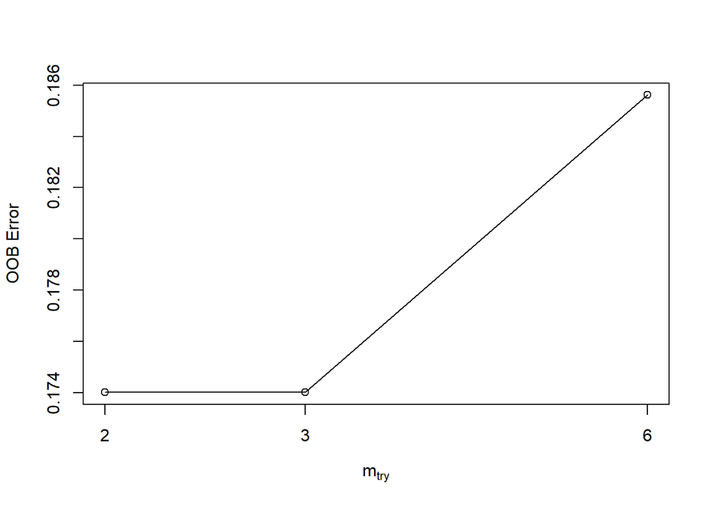

```r
val_opt <- min_tree_var [,"mtry"][which.min(min_tree_var [,"OOBError"])]

loan_rf <- randomForest(Loan_Status ~., data = training, importance = TRUE, ntree=500, mtry = val_opt)
loan_rf
```

```
##
## Call:
##  randomForest(formula = Loan_Status ~ ., data = training, importance = TRUE,      ntree = 500, mtry = val_opt)
##                Type of random forest: classification
##                      Number of trees: 500
## No. of variables tried at each split: 2
##
##         OOB estimate of  error rate: 16.71%
## Confusion matrix:
##    N   Y class.error
## N 72  63  0.46666667
## Y  9 287  0.03040541
```

Next we want to see if we have generated enough trees so that the Out Of Bag (OOB Error) error rates are minimum. From the below we see that the OOB error rate is decreasing with 1-20 trees, and rate stabilizes that at around 100 trees. Therefore for this dataset 500 trees is more than enough to minimize the OOB Error rate

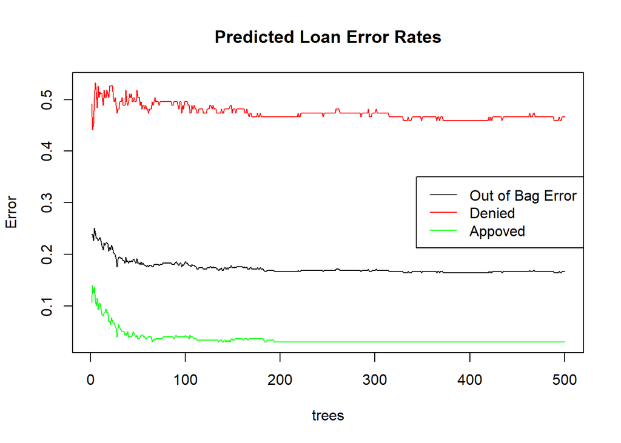

```r
plot(loan_rf, col = c("black", "red", "green"), lty = c(1, 1, 1), main = "Predicted Loan Error Rates")
legend("right", c(OOB = "Out of Bag Error", "Denied", "Appoved"), col = c("black", "red", "green"), lty = c(1, 1, 1))
```

An area of interest like Decision Trees is Variable importance, which is a scale of a given variable’s predictive power and is taken by taking the average purity of child nodes that the split causes across all trees in the forest. Variables with large increases in purity are considered more “important”

Below is a table of the predictor variables and their various importance factors. Some definitions to help understand the below table:

- Accuracy Decrease: the decrease in accuracy of the overall model if a given predictor is not used in the model
- Gini Decrease: For each split that is made using a given predictor there is a reduction in the Gini Index. The Gene Decrease is an average of this Gini Index reduction across the entire forest
- Mean_min_depth: The depth in a tree that a give node occurred in

```r
var_imp <- measure_importance(loan_rf)
var_imp[,1:7]
```

| variable | mean_min_depth | no_of_nodes | accuracy_decrease | gini_decrease | no_of_trees | times_a_root |
| --- | --- | --- | --- | --- | --- | --- |
| Credit_History | 1.824000 | 1858 | 0.1371878533 | 52.071318 | 500 | 92 |
| Dependents | 2.532000 | 3289 | 0.0014015100 | 7.919246 | 500 | 45 |
| Education | 3.447624 | 1860 | 0.0029192534 | 3.489593 | 499 | 28 |
| Gender | 3.599624 | 1835 | 0.0043058769 | 2.998180 | 499 | 11 |
| Loan_Amount_Term | 2.621248 | 2815 | 0.0012982178 | 6.810922 | 498 | 45 |
| LoanAmount | 2.160000 | 6060 | 0.0138253172 | 22.692679 | 500 | 68 |
| Married | 3.120000 | 1899 | 0.0052608994 | 3.782279 | 500 | 35 |
| Property_Area | 2.342000 | 2897 | 0.0042224026 | 7.411113 | 500 | 77 |
| Self_Employed | 3.956872 | 1863 | -0.0001211958 | 2.758903 | 497 | 10 |
| TotalIncome | 1.908000 | 6224 | 0.0183899741 | 26.694359 | 500 | 89 |

Predictors from the bootstrapped sample set that will give the highest purity are selected first. Credit History looks to be one of the most important predictors because:

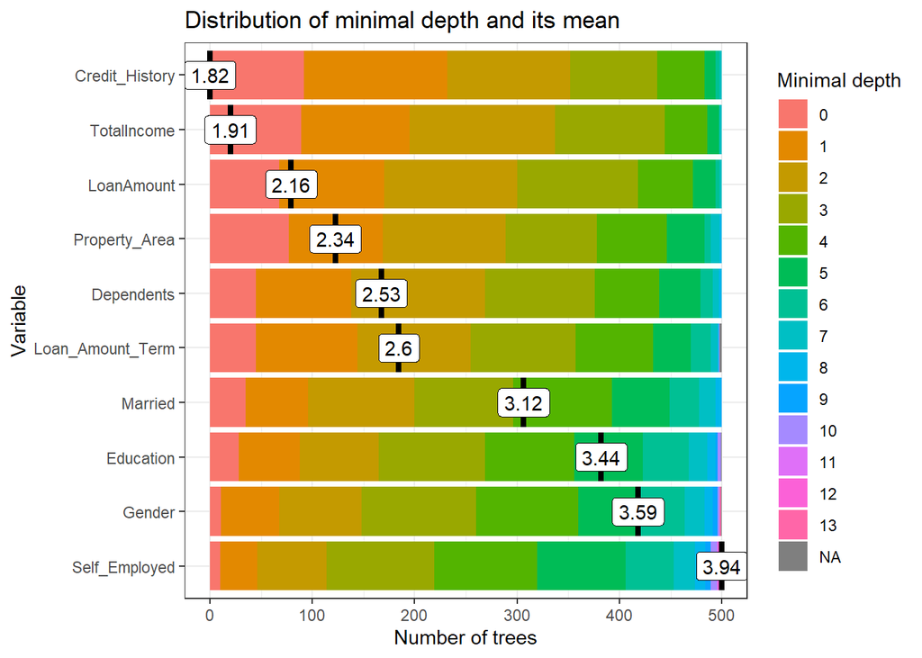

```r
plot_min_depth_distribution(min_depth_distribution(loan_rf), mean_sample = "relevant_trees")
```

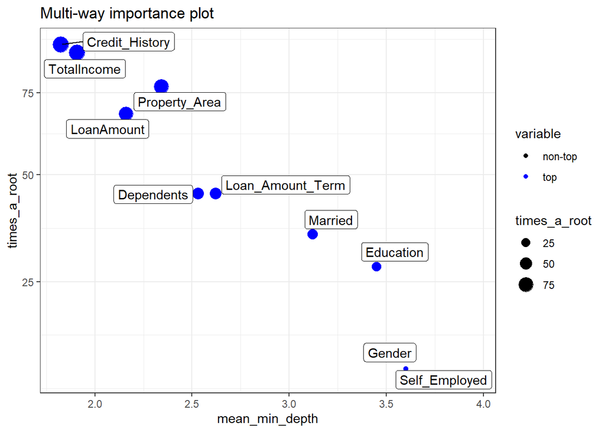

```r
plot_multi_way_importance(var_imp, size_measure = "times_a_root")
```

Looking at the multi-way importance plot we see that Credit History:

- has the largest accuracy decrease if the variable is omitted from model
- It has the highest Gini decrease of all variables

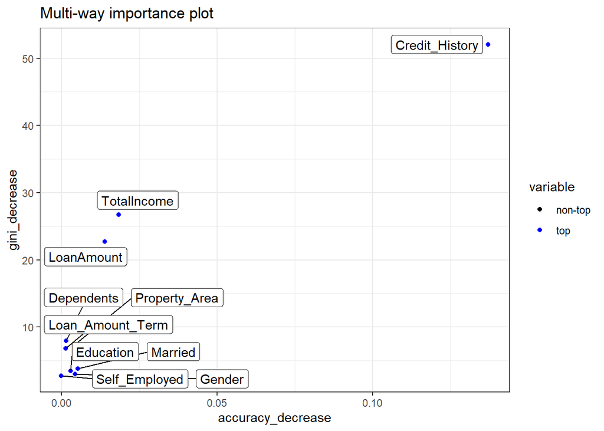

```r
plot_multi_way_importance(loan_rf, x_measure = "accuracy_decrease", y_measure = "gini_decrease")
```

Random Forest Accuracy

```r
loan_rf_pred <- predict(loan_rf, testing, type = "class")
loan_rf_table <- table(Actual = testing$Loan_Status, Predicted = loan_rf_pred)
loan_rf_table
```

```
##       Predicted
## Actual   N   Y
##      N  24  33
##      Y   4 122
```

```r
acc_rf <-  sum(diag(loan_rf_table))/sum(loan_rf_table)

cat("Accuracy: ", acc_rf)
```

```
## Accuracy:  0.7978142
```

```r
acc_df<- rbind(acc_df, data.frame(Model = "Random Forest", Accuracy = acc_rf))
```

## Gradient Boosting

This is another kind on ensemble algorithm in which several model are combined, but instead of running the model is parallel and then combining results, here model are run in series, with each output serving as an input to the next. With each new run of the classifier, the results are improved. Also, each classifiers performance can actually be rather low (shallow trees can be used for example), and with feeding the results to a new classifier, the overall effect is an improved performance.

Run gradient boost model

```r
set.seed(123)
loan_boost =gbm(Loan_Status ~., data = training,
              n.trees=500,
              interaction.depth=4,
                shrinkage=0.01,
              bag.fraction=0.5,
              distribution="multinomial",
              verbose=FALSE,
              cv.folds = 5,
              n.cores=2
              )
```

```r
# Check performance using 5-fold cross-validation
best.iter <- gbm.perf(loan_boost, method="cv")
```

[figure not shown]

```r
print(best.iter)
```

```
## [1] 116
```

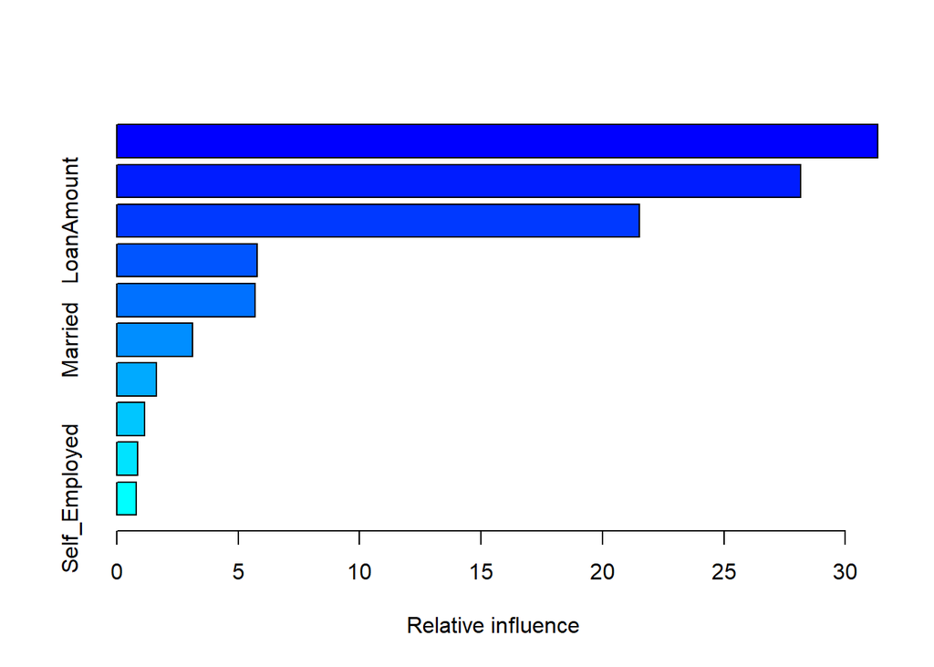

|  | var | rel.inf |
| --- | --- | --- |
| Credit_History | Credit_History | 31.3277283 |
| TotalIncome | TotalIncome | 28.1515699 |
| LoanAmount | LoanAmount | 21.5051686 |
| Dependents | Dependents | 5.7798622 |
| Property_Area | Property_Area | 5.6882716 |
| Married | Married | 3.1194388 |
| Education | Education | 1.6299187 |
| Gender | Gender | 1.1363026 |
| Loan_Amount_Term | Loan_Amount_Term | 0.8640642 |
| Self_Employed | Self_Employed | 0.7976751 |

```r
summary(loan_boost)
```

```r
pred = predict.gbm(loan_boost,
                    newdata = testing,
                    n.trees = best.iter,
                    type = "response")
```

```r
labels = colnames(pred)[apply(pred, 1, which.max)]
result = data.frame(testing$Loan_Status, labels)
cm = confusionMatrix(testing$Loan_Status, as.factor(labels))
print(cm)
```

```
## Confusion Matrix and Statistics
##
##           Reference
## Prediction   N   Y
##          N  23  34
##          Y   4 122
##
##                Accuracy : 0.7923
##                  95% CI : (0.7263, 0.8487)
##     No Information Rate : 0.8525
##     P-Value [Acc > NIR] : 0.9893
##
##                   Kappa : 0.4344
##
##  Mcnemar's Test P-Value : 2.546e-06
##
##             Sensitivity : 0.8519
##             Specificity : 0.7821
##          Pos Pred Value : 0.4035
##          Neg Pred Value : 0.9683
##              Prevalence : 0.1475
##          Detection Rate : 0.1257
##    Detection Prevalence : 0.3115
##       Balanced Accuracy : 0.8170
##
##        'Positive' Class : N
##
```

```r
#labels = colnames(pred)[apply(pred, 1, which.max)]
loan_boost_table <- table(Actual = testing$Loan_Status, Predicted = labels)
loan_boost_table
```

```
##       Predicted
## Actual   N   Y
##      N  23  34
##      Y   4 122
```

```r
acc_boost <-  sum(diag(loan_boost_table))/sum(loan_boost_table)
cat("Accuracy: ", acc_boost)
```

```
## Accuracy:  0.7923497
```

```r
acc_df <- rbind(acc_df, data.frame(Model = "Gradient Boosting", Accuracy = acc_boost))
```

## Model Performance

```r
acc_df
```

| Model | Accuracy |
| --- | --- |
| Base Decision Tree | 0.7322404 |
| Pruned Decision Tree | 0.7868852 |
| Random Forest | 0.7978142 |
| Gradient Boosting | 0.7923497 |